# Lab 05

Analysis of Env. Data

Elyse McCormick

2022-10-17

**Q1 (2 pts.): Show the R code you used to create exp_fun()**

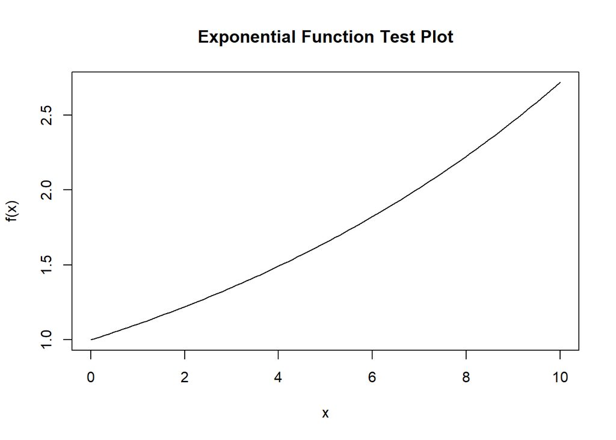

```r
exp_fun = function(x, a, b)
{
  return(a * exp(-b * x))
}
curve(
  exp_fun(x, 1, -1/10), from = 0, to = 10, add = FALSE,
  main = "Exponential Function Test Plot",
  xlab = "x", ylab = "f(x)")
```

**Q2 (4 pts.): In your lab report, include a single figure containing four negative exponential curves with different parameter values and line colors/textures.**

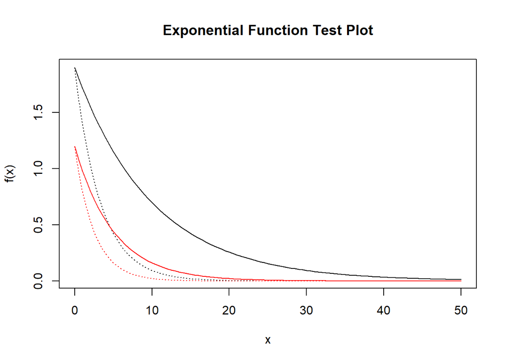

```r
curve(
  exp_fun(x, 1.9, 0.1), col = "black",
  from = 0, to = 50, add = FALSE, main = "Exponential Function Test Plot",
  xlab = "x", ylab = "f(x)")
curve(
  exp_fun(x, 1.9, 0.3), col = "black", lty = "dotted",
  from = 0, to = 50, add = TRUE)
curve(
  exp_fun(x, 1.2, 0.2), col = "red",
  from = 0, to = 50, add = TRUE)
curve(
  exp_fun(x, 1.2, 0.4), col = "red", lty = "dotted",
  from = 0, to = 50, add = TRUE)
```

**Q3 (2 pts.): Observe how the curves vary as you change the two parameters’ values. Qualitatively describe what happens to the curve as you vary parameter a**

As you vary parameter a, you see a different starting point on the y axis. For example, when a = 1.9, the black lines start near the top of the y axis. But when a = 1.2, the line starts near the midpoint of the y axis.

**Q4 (2 pts.): Observe how the curves vary as you change the two parameters’ values. Qualitatively describe what happens to the curve as you vary parameter b**

As you vary parameter b, it shifts the rate of decay, or the slope of the curve. For the black lines, when b = 0.1 the curve is more shallow than when b = 0.3. Similarly, for the red lines, when b = 0.2 the curve is more shallow than when b = 0.4

**Q5 (6 pts.): In your lab report, include a single plot containing 6 Ricker curves with different parameter values.**

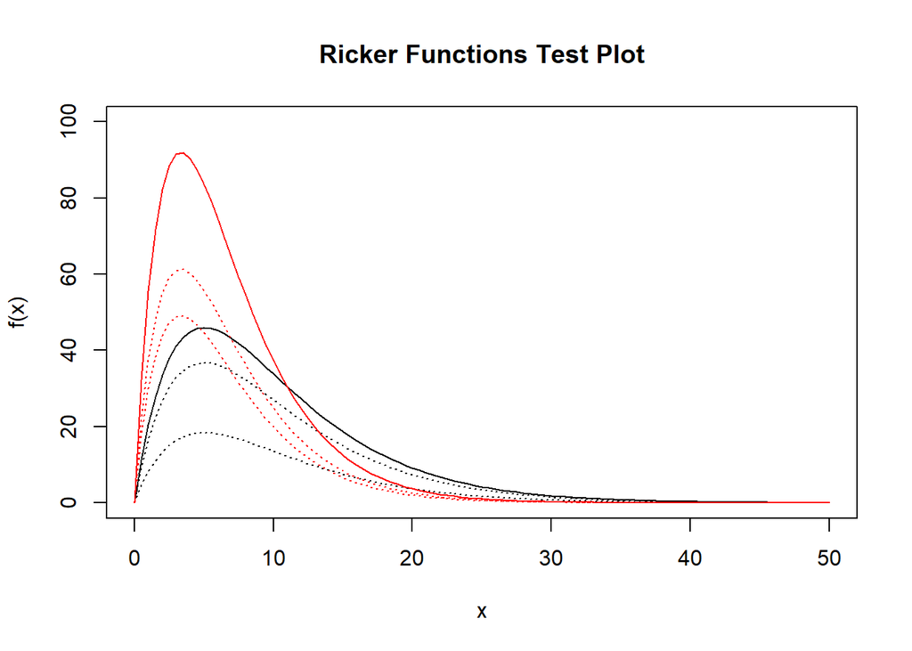

```r
ricker_fun = function(x, a, b)
{
  return(a * x * exp(-b * x))
}
curve(
  ricker_fun(x, 25, 0.2), col = "black",
  from = 0, to = 50, ylim = c(0, 100), add = FALSE, main = "Ricker Functions Test Plot",
  ylab = "f(x)", xlab = "x")
curve(
  ricker_fun(x, 20, 0.2), col = "black", lty = "dotted",
  from = 0, to = 50, ylim = c(0, 100), add = TRUE, main = "Ricker Functions Test Plot",
  ylab = "f(x)", xlab = "x")
curve(
  ricker_fun(x, 10, 0.2), col = "black", lty = "dotted",
  from = 0, to = 50, ylim = c(0, 100), add = TRUE, main = "Ricker Functions Test Plot",
  ylab = "f(x)", xlab = "x")
curve(
  ricker_fun(x, 75, 0.3), col = "red",
  from = 0, to = 50, ylim = c(0, 100), add = TRUE, main = "Ricker Functions Test Plot",
  ylab = "f(x)", xlab = "x")
curve(
  ricker_fun(x, 50, 0.3), col = "red", lty = "dotted",
  from = 0, to = 50, ylim = c(0, 100), add = TRUE, main = "Ricker Functions Test Plot",
  ylab = "f(x)", xlab = "x")
curve(
  ricker_fun(x, 40, 0.3), col = "red", lty = "dotted",
  from = 0, to = 50, ylim = c(0, 100), add = TRUE, main = "Ricker Functions Test Plot",
  ylab = "f(x)", xlab = "x")
```

**Q6 (2 pts.): Observe how the curves vary as you change the two parameters’ values. Qualitatively describe what happens to the curve as you vary parameter a**

As you vary parameter a, the slope of the curve varies. The highest peak exists for when a = 75, the lowest peak of the curves exists when a = 10.

**Q7 (2 pts.): Observe how the curves vary as you change the two parameters’ values. Qualitatively describe what happens to the curve as you vary parameter b**

**Q8 (2 pts.): Linear Model. Provide the values of the slope, x1, and y1 parameters you chose. Briefly describe how you chose the values.**

x1 = 1500 y1 = 0 slope = -0.00025

**Q9 (2 pts.): In your lab report, include a scatterplot of the salamander data with your fitted linear model.**

```r
require(psych)
require(here)
```

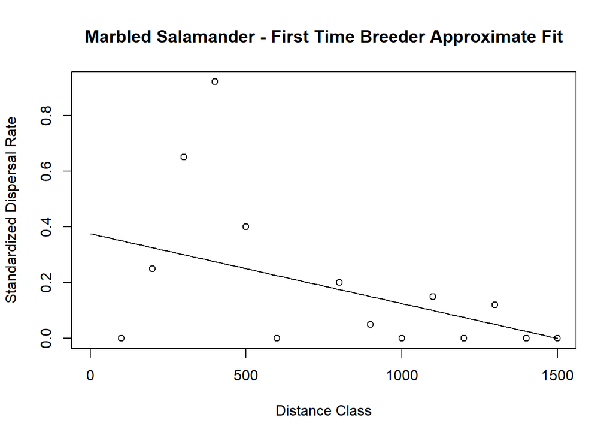

```r
sal_dat = read.csv(here("data", "dispersal.csv"))

plot(
  sal_dat$dist.class,
  sal_dat$disp.rate.ftb,
  xlim = c(0, 1500),
  xlab = "Distance Class",
  ylab = "Standardized Dispersal Rate",
  main = "Marbled Salamander - First Time Breeder Approximate Fit")
line_point_slope = function(x, x1, y1, slope)
{
  get_y_intercept =
    function(x1, y1, slope)
      return(-(x1 * slope) + y1)

  linear =
    function(x, yint, slope)
      return(yint + x * slope)

  return(linear(x, get_y_intercept(x1, y1, slope), slope))
}
curve(line_point_slope(x, 1500, 0, -0.00025), add = TRUE)
```

**Q10 (2 pts.): Exponential Model. Provide the values of the a and b. Briefly describe how you chose the values.**

a = 0.7 b = 1/300

I chose these values purely by trial and error of what might make the curve fit the data points best. Since a is where the curve crosses the y axis, you can play with b to see how to affect the shape of the curve. I played with the a and b values until they worked together to make a line that approximated the middle of the data.

**Q11 (2 pts.): In your lab report, include a scatterplot of the salamander data with your fitted exponential model.**

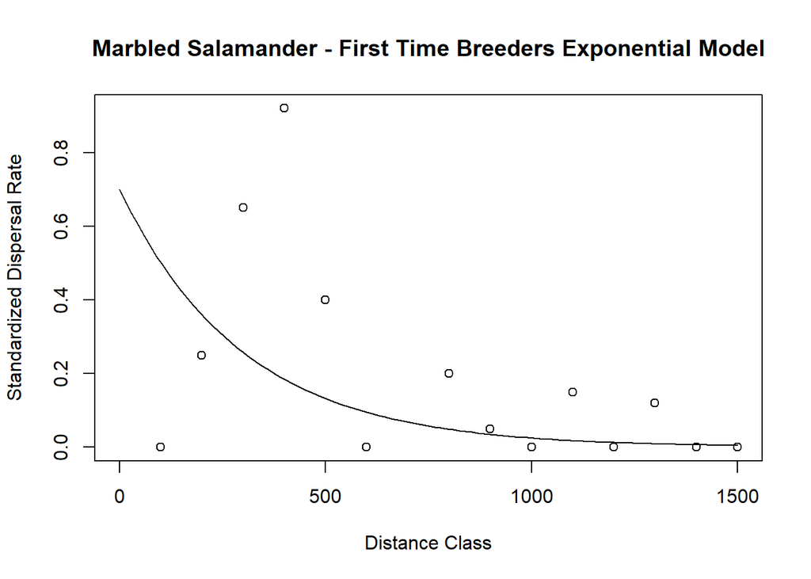

```r
plot(sal_dat$dist.class,
     sal_dat$disp.rate.ftb,
     xlim = c(0, 1500),
     xlab = "Distance Class",
     ylab = "Standardized Dispersal Rate",
     main = "Marbled Salamander - First Time Breeders Exponential Model")
exp_fun = function(x, a, b)
     {
       return(a * exp(-b * x))
     }
curve(exp_fun(x, 0.7, 1/300), from = 0, to = 1500, add = TRUE)
```

**Q12 (2 pts.): Ricker Model Provide the values of the a and b. Briefly describe how you chose the values.**

**Q13 (2 pts.): In your lab report, include a scatterplot of the salamander data with your fitted Ricker model.**

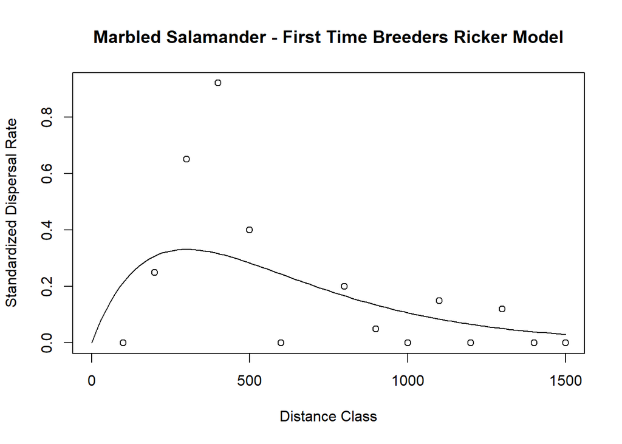

```r
plot(sal_dat$dist.class,
     sal_dat$disp.rate.ftb,
     xlim = c(0, 1500),
     xlab = "Distance Class",
     ylab = "Standardized Dispersal Rate",
     main = "Marbled Salamander - First Time Breeders Ricker Model")
ricker_fun = function(x, a, b)
{
  return(a * x * exp(-b * x))
}
curve(
  ricker_fun(x, 0.003, 1/300), from = 0, to = 1500, add = TRUE)
```

**Q14 (4 pts.): Show the R code you used to create your data frame of model residuals.**

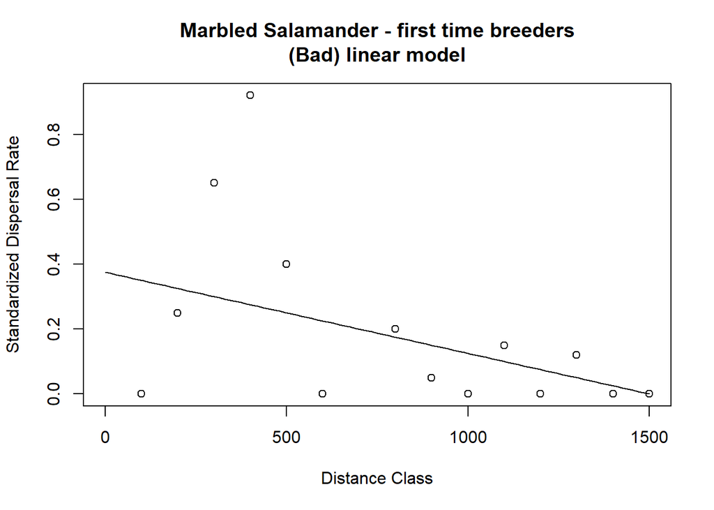

```r
guess_x = 1500
guess_y = 0
guess_slope = -0.00025

plot(
  sal_dat$dist.class,
  sal_dat$disp.rate.ftb,
  xlim = c(0, 1500),
  xlab = "Distance Class",
  ylab = "Standardized Dispersal Rate",
  main = "Marbled Salamander - first time breeders\n(Bad) linear model")
line_point_slope = function(x, x1, y1, slope)
{
  get_y_intercept =
    function(x1, y1, slope)
      return(-(x1 * slope) + y1)

  linear =
    function(x, yint, slope)
      return(yint + x * slope)

  return(linear(x, get_y_intercept(x1, y1, slope), slope))
}
curve(line_point_slope(x, 1500, 0, -0.00025), add = TRUE)
```

```r
line_point_slope(sal_dat$dist.class, guess_x, guess_y, guess_slope)
```

```
##  [1] 0.350 0.325 0.300 0.275 0.250 0.225 0.200 0.175 0.150 0.125 0.100 0.075
## [13] 0.050 0.025 0.000
```

```r
sal_dat$y_predicted = line_point_slope(sal_dat$dist.class, guess_x, guess_y, guess_slope)

sal_dat$resids_linear = sal_dat$disp.rate.ftb - sal_dat$y_predicted

sum(sal_dat$resids_linear, na.rm = TRUE)
```

```
## [1] 0.315
```

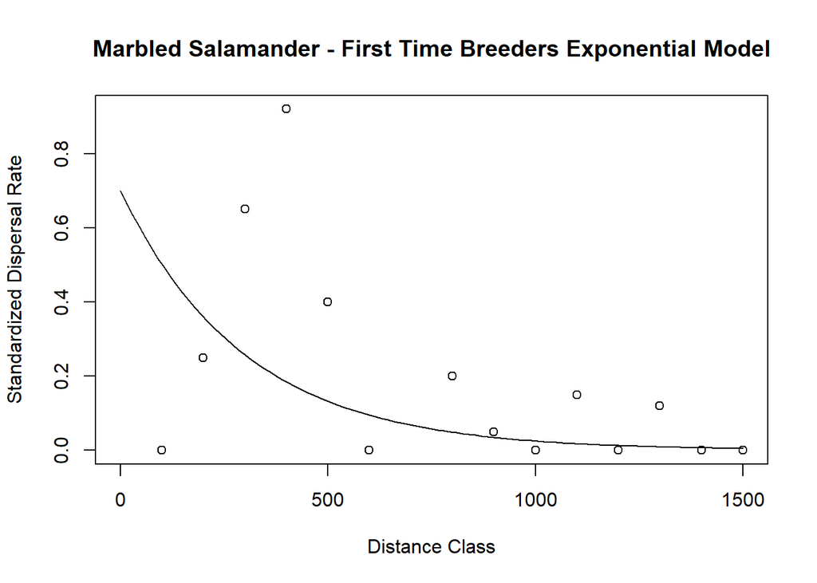

```r
#plot( x = sal_dat$disp.rate.ftb, xlab = "Observed", y = sal_dat$resids, ylab = "Residuals", pch = 8)

#hist(sal_dat$resids_linear, xlab = "Residuals", main = "Histogram of Linear Residuals")

guess_xe = 300
guess_a = 0.7
guess_b = 1/300

plot(sal_dat$dist.class,
     sal_dat$disp.rate.ftb,
     xlim = c(0, 1500),
     xlab = "Distance Class",
     ylab = "Standardized Dispersal Rate",
     main = "Marbled Salamander - First Time Breeders Exponential Model")
exp_fun = function(x, a, b)
{
  return(a * exp(-b * x))
}
curve(exp_fun(x, 0.7, 1/300), from = 0, to = 1500, add = TRUE)
```

```r
line_point_slope(sal_dat$dist.class, guess_x, guess_a, guess_b)
```

```
##  [1] -3.96666667 -3.63333333 -3.30000000 -2.96666667 -2.63333333 -2.30000000
##  [7] -1.96666667 -1.63333333 -1.30000000 -0.96666667 -0.63333333 -0.30000000
## [13]  0.03333333  0.36666667  0.70000000
```

```r
sal_dat$ey_predicted = line_point_slope(sal_dat$dist.class,guess_xe, guess_a, guess_b)

sal_dat$resids_exp = sal_dat$disp.rate.ftb - sal_dat$ey_predicted

sum(sal_dat$resids_exp, na.rm = TRUE)
```

```
## [1] -30.72667
```

```r
sum(abs(sal_dat$resids_exp))
```

```
## [1] NA
```

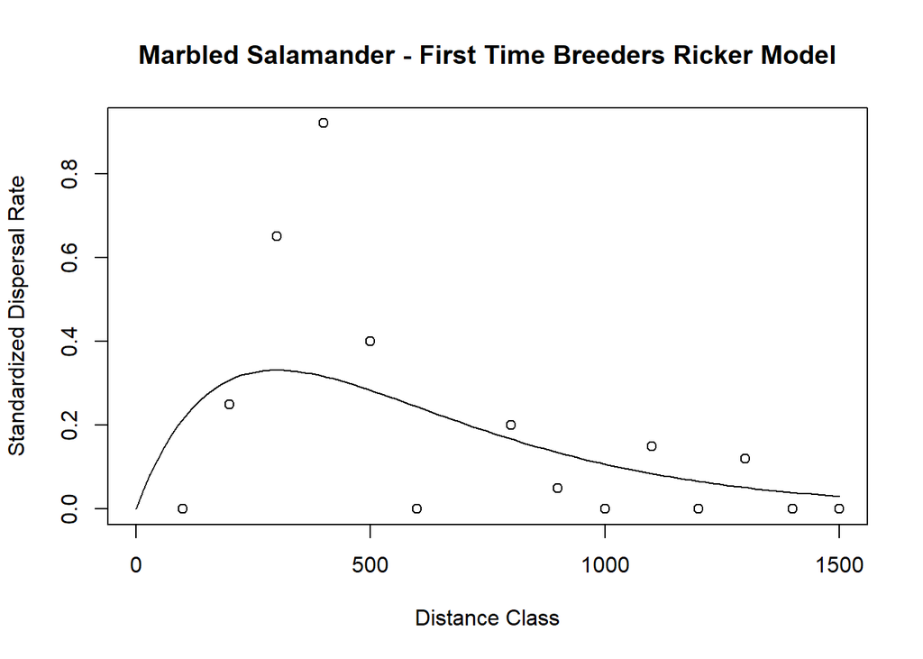

```r
#plot( x = sal_dat$disp.rate.ftb, xlab = "Observed", y = sal_dat$resids_exp, ylab = "Residuals", pch = 8)

#hist(sal_dat$resids_exp, xlab = "Residuals", main = "Histogram of Exp Residuals")

guess_xr = 300
guess_ar = 0.003
guess_br = 1/300

plot(sal_dat$dist.class,
     sal_dat$disp.rate.ftb,
     xlim = c(0, 1500),
     xlab = "Distance Class",
     ylab = "Standardized Dispersal Rate",
     main = "Marbled Salamander - First Time Breeders Ricker Model")
ricker_fun = function(x, a, b)
{
  return(a * x * exp(-b * x))
}
curve(
  ricker_fun(x, 0.003, 1/300), from = 0, to = 1500, add = TRUE)
```

```r
line_point_slope(sal_dat$dist.class, guess_xr, guess_ar, guess_br)
```

```
##  [1] -0.6636667 -0.3303333  0.0030000  0.3363333  0.6696667  1.0030000
##  [7]  1.3363333  1.6696667  2.0030000  2.3363333  2.6696667  3.0030000
## [13]  3.3363333  3.6696667  4.0030000
```

```r
sal_dat$ry_predicted = line_point_slope(sal_dat$dist.class,guess_xr, guess_ar, guess_br)

sal_dat$resids_ricker = sal_dat$disp.rate.ftb - sal_dat$ry_predicted

sum(sal_dat$resids_ricker, na.rm = TRUE)
```

```
## [1] -20.96867
```

```r
sum(abs(sal_dat$resids_ricker))
```

```
## [1] NA
```

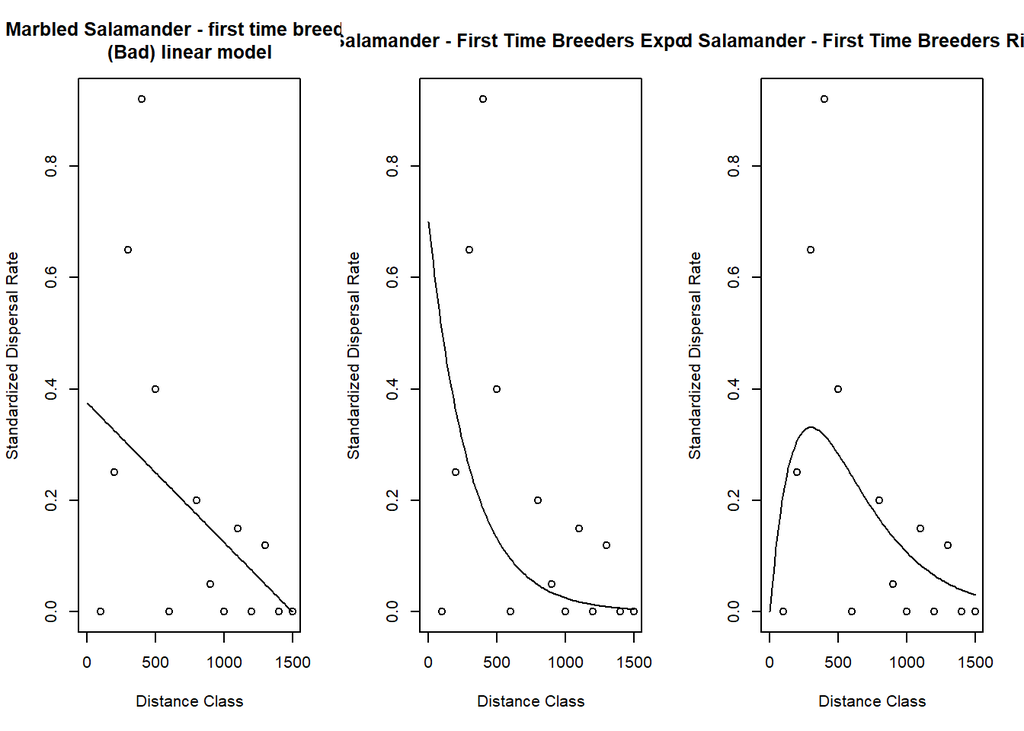

```r
#plot( x = sal_dat$disp.rate.ftb, xlab = "Observed", y = sal_dat$resids_ricker, ylab = "Residuals", pch = 8)

par(mfrow = c(1,3))
plot(
  sal_dat$dist.class,
  sal_dat$disp.rate.ftb,
  xlim = c(0, 1500),
  xlab = "Distance Class",
  ylab = "Standardized Dispersal Rate",
  main = "Marbled Salamander - first time breeders\n(Bad) linear model")
line_point_slope = function(x, x1, y1, slope)
{
  get_y_intercept =
    function(x1, y1, slope)
      return(-(x1 * slope) + y1)

  linear =
    function(x, yint, slope)
      return(yint + x * slope)

  return(linear(x, get_y_intercept(x1, y1, slope), slope))
}
curve(line_point_slope(x, 1500, 0, -0.00025), add = TRUE)
plot(sal_dat$dist.class,
     sal_dat$disp.rate.ftb,
     xlim = c(0, 1500),
     xlab = "Distance Class",
     ylab = "Standardized Dispersal Rate",
     main = "Marbled Salamander - First Time Breeders Exponential Model")
exp_fun = function(x, a, b)
{
  return(a * exp(-b * x))
}
curve(exp_fun(x, 0.7, 1/300), from = 0, to = 1500, add = TRUE)
plot(sal_dat$dist.class,
     sal_dat$disp.rate.ftb,
     xlim = c(0, 1500),
     xlab = "Distance Class",
     ylab = "Standardized Dispersal Rate",
     main = "Marbled Salamander - First Time Breeders Ricker Model")
ricker_fun = function(x, a, b)
{
  return(a * x * exp(-b * x))
}
curve(
  ricker_fun(x, 0.003, 1/300), from = 0, to = 1500, add = TRUE)
```

**Q15 (3 pts.): In your lab report, include histograms of the residuals for each of your three models. You may create a single figure with three panels, or include three separate figures.**

[figure not shown]

```r
par(mfrow = c(1, 3))
hist(sal_dat$resids_linear, xlab = "Residuals", main = "Histogram of Linear Residuals", col = "red")
hist(sal_dat$resids_exp, xlab = "Residuals", main = "Histogram of Exp Residuals", col = "yellow")
hist(sal_dat$resids_exp, xlab = "Residuals", main = "Histogram of Ricker Residuals", col = "blue")
```